# Metagenome assignment for IBS574 - Mohamed Tageldin

# ——————————————————

# PART1: Checking FastQ quality scores:

# ——————————————————

```r
# reset workspace
rm(list=ls())
# set project paths
ProjectPath = "/home/mtageld/Desktop/MetaGenome_class/"
DataPath = paste(ProjectPath, "Data/P00134/", sep="")
ResultsPath = paste(ProjectPath, "Results/", sep="")
```

Note, before running this script I copied the files and unzipped them using the command gunzip

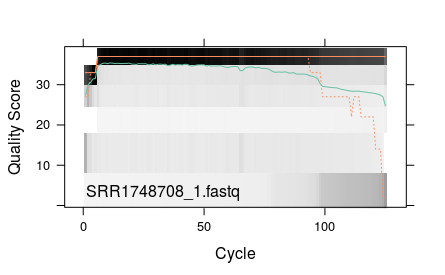

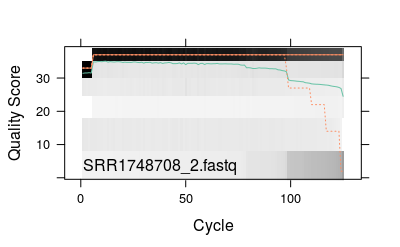

```r
library("ShortRead")
# list directory contents
l = list.files(DataPath)
for (i in 1:length(l)){
arg <- paste(DataPath, toString(l[i]), sep="")
#make sure that exactly arg is entered
if (length(arg) > 1){
  stop('Stop: More than one file entered')
}
if (length(arg)== 0){
  stop('Stop: n files entered')
}
qqF <- qa(arg) #quality assessment
qqf.pc.qual <- qqF[["perCycle"]]$quality
#pdf(paste(ResultsPath, toString(l[i]), "q-graph.pdf", sep=""))
print(ShortRead:::.plotCycleQuality(qqf.pc.qual))
#dev.off()
}
```

# ——————————————————

# PART2: Kraken analysis

# ——————————————————

ran this from the command line after cd’ing to the ResultOath

kraken –db /home/Shared/IBS574/TDR-metagenome-practical/minikraken_20141208 –fastq-input –gzip-compressed –classified-out ./krak_classified_reads –paired /home/Shared/IBS574/TDR-metagenome-practical/P00134/SRR1748708_1.fastq.gz /home/Shared/IBS574/TDR-metagenome-practical/P00134/SRR1748708_2.fastq.gz > ./kraken_out

kraken-report –db /home/Shared/IBS574/TDR-metagenome-practical/minikraken_20141208 ./kraken_out > kraken_report

```r
# check the three output files
print(list.files(ResultsPath, "krak*"))
```

```
[1] "krak_classified_reads" "kraken_out"
[3] "kraken_report"
```

Now moving on to script by Anna Knight to pull out the reads that match the pathogens

```r
library("Biostrings")
#my krak_classified_reads were in fastq format
readPath = paste(ResultsPath, "krak_classified_reads", sep="")
reportPath = paste(ResultsPath, "kraken_report", sep="")
outPath = paste(ResultsPath, "kraken_out", sep="")
reads<-readDNAStringSet(readPath, format ="fasta")
report<-read.table(reportPath, sep="\t", as.is=T)
```

```
EOF within quoted string
```

```r
a<-read.table(outPath,sep = "\t", as.is=T)
a1<-a[,2:3]
anthrax<-subset(a1, a1$V3==1392)
pestis<-subset(a1, a1$V3==632)

anthrax2<-as.character(anthrax$V2)
pestis2<-as.character(pestis$V2)

writeXStringSet(reads[names(reads) %in% pestis2],paste(ResultsPath,"Ypestis.fasta",sep=""))
writeXStringSet(reads[names(reads) %in% anthrax2],paste(ResultsPath,"Banthracis.fasta",sep=""))
```

```r
# check the three output files
print(list.files(ResultsPath, "*.fasta"))
```

```
[1] "Banthracis.fasta" "Ypestis.fasta"
```

ran this from the command line to BLAST the fasta files to check if they are specific to these pathogenic species or if there are other species that have these same sequences

blastn -db /home/Shared/IBS574/BlastDB/nt -query Ypestis.fasta -outfmt “6 stitle qseqid sseqid pident length mismatch gapopen qstart qend sstart send evalue bitscore staxids” >Blastouputoestis2

awk ‘{print $1,$2}’ Blastouputoestis2 | sort | uniq

blastn -db /home/Shared/IBS574/BlastDB/nt -query Banthracis.fasta -outfmt “6 stitle qseqid sseqid pident length mismatch gapopen qstart qend sstart send evalue bitscore staxids” >Blastoutputanthrax2

awk ‘{print $1,$2}’ Blastoutputanthrax2 | sort | uniq

```r
# check the output files
print(list.files(ResultsPath, "Blast*"))
```

```
[1] "Blastouputoestis2"   "Blastoutputanthrax2"
```

The read for Y. pestis did not match anything (returned empty file, indicating it wasn’t present in the dataset I decided to use in the firt place -P00134-) but the reading for B. anthacis resulted in many, many species and strains, so this is not specific.

# ——————————————————

# PART3: Munging data using R

# ——————————————————

```r
# opening the excel file
 temp.csv <- read.csv("/home/Shared/IBS574/TDR-metagenome-practical/DataTable5-metaphlan-metadata_v19.csv",stringsAsFactors = FALSE, header = TRUE)
# Looking at the file
head(temp.csv)
```

|  | Sample.ID | Description | Latitude | Logitude | Line..Station.Only. | X2013.Avg.Weekday.Ridership..Station.Only. | Object.Category | Borough | Object.Swabbed | Surface.Material | Ground.Level..Station.Only. | Mean.Air.Temp..F. | Mean.Abs.Humidity | Mean.Dew.Point | Traffic..Station.Only. | Date.of.Collection | Zip.Code..Station.Only. | Sequence | Read.Length | Total...of.Reads | Sequence.1 | Read.Length.1 | Total...of.Reads.1 | Sequence.2 | Read.Length.2 | Total...of.Reads.2 | X | X.1 | ID | … |
| --- | --- | --- | --- | --- | --- | --- | --- | --- | --- | --- | --- | --- | --- | --- | --- | --- | --- | --- | --- | --- | --- | --- | --- | --- | --- | --- | --- | --- | --- | --- |
| 1 | Culture01 | 68 St-Hunter College (LB @ 28C) | 40.768141 | -73.96387 | 6 | 36562 | Culture | Manhattan | Turnstile | Metal | Underground | 45 | 54 | 26 | #N/A | 26-Mar-14 | 10021 | Illumina MiSeq | 301x301 | 2514700 |  |  | NA |  |  | NA | NA | NA | Culture01 | … |
| 2 | Culture02 | 68 St-Hunter College (LB & Tetracycline @ 28C) | 40.768141 | -73.96387 | 6 | 36562 | Culture | Manhattan | Turnstile | Metal | Underground | 45 | 54 | 26 | #N/A | 26-Mar-14 | 10021 | Illumina MiSeq | 301x301 | 2579092 |  |  | NA |  |  | NA | NA | NA | Culture02 | … |
| 3 | Culture03 | 68 St-Hunter College (TSA & Tetracycline @ 28C) | 40.768141 | -73.96387 | 6 | 36562 | Culture | Manhattan | Turnstile | Metal | Underground | 45 | 54 | 26 | #N/A | 26-Mar-14 | 10021 | Illumina MiSeq | 301x301 | 2373418 |  |  | NA |  |  | NA | NA | NA | Culture03 | … |
| 4 | Culture05 | 68 St-Hunter College (TSA @ 37C) | 40.768141 | -73.96387 | 6 | 36562 | Culture | Manhattan | Turnstile | Metal | Underground | 45 | 54 | 26 | #N/A | 26-Mar-14 | 10021 | Illumina MiSeq | 301x301 | 2535803 |  |  | NA |  |  | NA | NA | NA | Culture05 | … |
| 5 | Culture07 | 77 st (LB @ 28C) | 40.77362 | -73.959874 | 6 | 37182 | Culture | Manhattan | Turnstile | Metal | Underground | 45 | 54 | 26 | #N/A | 26-Mar-14 | 10075 | Illumina MiSeq | 301x301 | 2491927 |  |  | NA |  |  | NA | NA | NA | Culture07 | … |
| 6 | Culture08 | 77 st (LB @ 35C) | 40.77362 | -73.959874 | 6 | 37182 | Culture | Manhattan | Turnstile | Metal | Underground | 45 | 54 | 26 | #N/A | 26-Mar-14 | 10075 | Illumina MiSeq | 301x301 | 2534428 |  |  | NA |  |  | NA | NA | NA | Culture08 | … |

```r
# isolating genus-level information (columns starting with g_ but not s_)
genera <- setdiff(grep("g__",colnames(temp.csv)),grep("s__",colnames(temp.csv)))
Genera <- temp.csv[genera]
# look at it
head(colnames(Genera))
```

```
[1] "k__Archaea.p__Euryarchaeota.c__Methanobacteria.o__Methanobacteriales.f__Methanobacteriaceae.g__Methanobrevibacter"
[2] "k__Archaea.p__Euryarchaeota.c__Methanomicrobia.o__Methanomicrobiales.f__Methanocorpusculaceae.g__Methanocorpusculum"
[3] "k__Archaea.p__Euryarchaeota.c__Methanomicrobia.o__Methanomicrobiales.f__Methanomicrobiaceae.g__Methanoplanus"
[4] "k__Archaea.p__Euryarchaeota.c__Methanomicrobia.o__Methanosarcinales.f__Methanosaetaceae.g__Methanosaeta"
[5] "k__Archaea.p__Euryarchaeota.c__Methanomicrobia.o__Methanosarcinales.f__Methanosarcinaceae.g__Methanolobus"
[6] "k__Archaea.p__Euryarchaeota.c__Methanomicrobia.o__Methanosarcinales.f__Methanosarcinaceae.g__Methanosarcina"
```

```r
# What were the 20 most common bacterial genus discovered in the study (in terms of the number of samples where the genus was identified as > 0% of the microbiome)?
# looking at the number of hits for each species
GenSum <- apply(Genera>0,2,sum)
# Adding a column index column so when we sort we can keep track of which species was where
GenSum <- cbind(GenSum,1:length(GenSum))
# sort based on abundance
GenSum <- GenSum[order(GenSum[,1]),]
# Getting indices of most abundant species
Idx <- GenSum[(dim(GenSum)[1]-19):(dim(GenSum)[1]),2]
colnames(Genera)[Idx]
```

```
 [1] "k__Bacteria.p__Proteobacteria.c__Gammaproteobacteria.o__Oceanospirillales.f__Halomonadaceae.g__Halomonas"
 [2] "k__Bacteria.p__Firmicutes.c__Bacilli.o__Lactobacillales.f__Aerococcaceae.g__Aerococcus"
 [3] "k__Bacteria.p__Firmicutes.c__Clostridia.o__Clostridiales.f__Clostridiaceae.g__Clostridium"
 [4] "k__Bacteria.p__Actinobacteria.c__Actinobacteria.o__Actinomycetales.f__Dermatophilaceae.g__Dermatophilaceae_unclassified"
 [5] "k__Bacteria.p__Firmicutes.c__Bacilli.o__Lactobacillales.f__Leuconostocaceae.g__Leuconostoc"
 [6] "k__Bacteria.p__Firmicutes.c__Bacilli.o__Bacillales.f__Staphylococcaceae.g__Staphylococcus"
 [7] "k__Bacteria.p__Bacteroidetes.c__Sphingobacteriia.o__Sphingobacteriales.f__Sphingobacteriaceae.g__Sphingobacterium"
 [8] "k__Bacteria.p__Firmicutes.c__Bacilli.o__Bacillales.f__Bacillales_noname.g__Exiguobacterium"
 [9] "k__Bacteria.p__Firmicutes.c__Bacilli.o__Bacillales.f__Bacillaceae.g__Bacillus"
[10] "k__Bacteria.p__Proteobacteria.c__Alphaproteobacteria.o__Caulobacterales.f__Caulobacteraceae.g__Brevundimonas"
[11] "k__Bacteria.p__Proteobacteria.c__Betaproteobacteria.o__Burkholderiales.f__Oxalobacteraceae.g__Massilia"
[12] "k__Bacteria.p__Proteobacteria.c__Gammaproteobacteria.o__Enterobacteriales.f__Enterobacteriaceae.g__Klebsiella"
[13] "k__Bacteria.p__Proteobacteria.c__Gammaproteobacteria.o__Enterobacteriales.f__Enterobacteriaceae.g__Pantoea"
[14] "k__Bacteria.p__Firmicutes.c__Bacilli.o__Bacillales.f__Bacillaceae.g__Lysinibacillus"
[15] "k__Bacteria.p__Proteobacteria.c__Gammaproteobacteria.o__Enterobacteriales.f__Enterobacteriaceae.g__Escherichia"
[16] "k__Bacteria.p__Firmicutes.c__Bacilli.o__Lactobacillales.f__Enterococcaceae.g__Enterococcus"
[17] "k__Bacteria.p__Proteobacteria.c__Gammaproteobacteria.o__Enterobacteriales.f__Enterobacteriaceae.g__Enterobacter"
[18] "k__Bacteria.p__Proteobacteria.c__Gammaproteobacteria.o__Xanthomonadales.f__Xanthomonadaceae.g__Stenotrophomonas"
[19] "k__Bacteria.p__Proteobacteria.c__Gammaproteobacteria.o__Pseudomonadales.f__Moraxellaceae.g__Acinetobacter"
[20] "k__Bacteria.p__Proteobacteria.c__Gammaproteobacteria.o__Pseudomonadales.f__Pseudomonadaceae.g__Pseudomonas"
```

```r
#  What was the most common genus found in Brooklyn?
# Isolate genera from Brooklyn
Genera_Brooklyn <- Genera[temp.csv$Borough == "Brooklyn",]
# looking at the number of hits for each species
GenSum <- apply(Genera_Brooklyn>0,2,sum)
# Adding a column index column so when we sort we can keep track of which species was where
GenSum <- cbind(GenSum,1:length(GenSum))
# sort based on abundance
GenSum <- GenSum[order(GenSum[,1]),]
# Getting indices of most abundant species
#Idx <- GenSum[(dim(GenSum)[1]-19):(dim(GenSum)[1]),2]
colnames(Genera)[dim(GenSum)[1]]
```

```
[1] "k__Viruses.p__Viruses_noname.c__Viruses_noname.o__Viruses_noname.f__Viruses_noname.g__Viruses_noname"
```

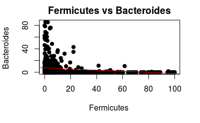

```r
#  Make a scatterplot of the proportion of the phyla Firmicutes and Bacteroidetes in each sample.
# isolating phylum-level information (columns starting with g_ but not s_)
ferm <- setdiff(grep("p__Firmicutes",colnames(temp.csv)),grep("c__",colnames(temp.csv)))
bact <- setdiff(grep("p__Bacteroidetes",colnames(temp.csv)),grep("c__",colnames(temp.csv)))
Phyla <- temp.csv[c(ferm,bact)]
# Plot
plot(Phyla[,1], Phyla[,2], main="Fermicutes vs Bacteroides",
    xlab="Fermicutes ", ylab="Bacteroides ", pch=19)
# Add regression fit line
abline(lm(Phyla[,1]~Phyla[,2]), col="red")
```